# HW1_B66043

Dzvezdana Arsovska

February 12, 2017

## *Exercise 1*

Familiarize yourself with the course and do all the necessary administrative things.

Read all the material in the courses page, definitely:

- GENERAL INFO
- HOMEWORK FORMAT
- ABOUT PLAGIARISM
- SUBMISSION RULES
- SOFTWARE, especially about HOW TO CHOOSE LANGUAGE

Make sure you are registered to Piazza (if you are not then you lose points for this task).

**Solution:**

To get full points for the report we need to follow the report format. The report should contain a separate section for each homework task (we have to provide explanation of the problem, explanation of how you solved the problem, explanation of what was the outcome and comments and conclusions about the outcome ). Also explanations should be accompanied by and based on graphs, plots, tables and code has to be provided for all coding tasks. Points will be deducted if we are late with the submission, don’t have both report and code, don’t follow the submission rules, don’t answer to all of the questions asked, don’t explain what we did and the outcome or we haven’t included the important code parts in the report. In addition we can increase our homework score if we have a good presentation during the presentation session.

*I will not plagiarize.*

*I understand and will follow the submission rules.*

*I have registered to Piazza.*

## *Exercise 2*

Using R complete the following tasks:

1. What are the column names of the dataset?
2. How many observations (i.e. rows) are in this data frame?
3. Print the first 4 lines from the dataset. What are the values of feature rings of the printed observations?
4. Extract the last 3 rows of the data frame. What is the weight of these abalones?
5. What is the value of diameter in the row 755?
6. How many missing values are in the height column?
7. What is the mean of the height column? Exclude missing values from this calculation.
8. Extract the subset of rows of the data frame where gender is M and weight values are below 0.75. What is the mean of diameter in this subset?
9. What is the most frequent rings value?
10. What is the minimum of length when rings is equal to 18?

**Solution:**

```r
X <- read.csv(url("https://courses.cs.ut.ee/MTAT.03.183/2017_spring/uploads/Main/abalone.csv"))

# The column names in the data set are:
colnames(X)
```

```
## [1] "Gender"   "Length"   "Diameter" "Height"   "Weight"   "Rings"
```

```r
# The number of rows is:
nrow(X)
```

```
## [1] 1000
```

```r
f4_rows = head(X, n = 4)
# The first 4 rows are:
f4_rows
```

```
##   Gender Length Diameter Height Weight Rings
## 1      F  0.505    0.385  0.135 0.6185    12
## 2      F  0.650    0.475  0.165 1.3875     9
## 3      I  0.520    0.380  0.135 0.5395     8
## 4      F  0.550    0.425  0.140 0.9520     7
```

```r
# The values of the rings in this subset is:
f4_rows$Rings
```

```
## [1] 12  9  8  7
```

```r
l4_row = tail(X, n = 3)
# The last 3 row are:
l4_row
```

```
##      Gender Length Diameter Height Weight Rings
## 998       M  0.660    0.500  0.165 1.3195     9
## 999       I  0.525    0.400  0.130 0.6455     8
## 1000      M  0.515    0.395  0.135 1.0070     8
```

```r
# The values of the weight in this subset is:
l4_row$Weight
```

```
## [1] 1.3195 0.6455 1.0070
```

```r
ELEMENT_val = X[755, 3]
# The value of the diameter in the row 755 is:
ELEMENT_val
```

```
## [1] 0.385
```

```r
Height_col = X$Height
# The number of the missing values in the height column is:
table(is.na(Height_col))
```

```
##
## FALSE  TRUE
##   996     4
```

```r
# The mean of the height column is:
mean(Height_col, na.rm = TRUE)
```

```
## [1] 0.1398092
```

```r
newdata <- X[which(X$Gender == "M" & X$Weight < 0.75), ]
# The subset of rows of the data where gender = M and weight values < 0.75
# is:
newdata
```

```
##     Gender Length Diameter Height Weight Rings
## 12       M  0.400    0.310  0.110 0.3140    11
## 13       M  0.460    0.360  0.125 0.5470     8
## 17       M  0.540    0.420  0.155 0.7385    12
## 19       M  0.345    0.255  0.090 0.2005     9
## 23       M  0.465    0.360  0.110 0.4955     7
## 37       M  0.490    0.385  0.125 0.6490     8
## 42       M  0.505    0.405  0.110 0.6250     9
## 59       M  0.430    0.310  0.130 0.6485     9
## 72       M  0.360    0.270  0.100 0.2170     6
## 74       M  0.470    0.375  0.130 0.5230     8
## 93       M  0.430    0.345  0.115 0.3045    11
## 94       M  0.565    0.425  0.100 0.7145    12
## 97       M  0.480    0.375  0.115 0.6765     6
## 127      M  0.485    0.410  0.150 0.6960    13
```

[output cut: 105 more lines]

```r
new_diam = newdata$Diameter
# The mean of diameter in this subset is:
mean(new_diam)
```

```
## [1] 0.3426471
```

```r
r_vall <- tail(names(sort(table(X$Rings))), 1)
# The most frequent rings value is:
r_vall
```

```
## [1] "9"
```

```r
newdata1 <- X[which(X$Rings == 18), ]
# The minimum of length when rings is equal to 18 is:
min(newdata1[, 2])
```

```
## [1] 0.465
```

## *Exercise 3*

Repeat the tasks from **a** to **j** using **Python**.

**Solution:**

```python
import pandas as pd

data = pd.read_csv('https://courses.cs.ut.ee/2017/dm/spring/uploads/Main/abalone.csv')

#a
col_names=data.columns.values.tolist()

#b
row_num=data.shape[0]

#c
first4_r=data.head(4)
slice_col=first4_r.loc[: , "Rings"]

#d
last4_c=data.tail(3)
slice_col1=last4_c.loc[: , "Weight"]

#e
value_dim=data.iloc[754,2]

#f
slice_height=data.loc[: , "Height"]
num_nan=slice_height.isnull().sum()

#g
m=data["Height"].mean()

#h
cr=data[(data.Gender == 'M') & (data.Weight<0.75)]
m2=cr["Diameter"].mean()

#i
fr_val=data['Rings'].value_counts().idxmax()

#j
c_rings=data[data.Rings == 18]
c_len=c_rings.loc[: , "Length"]
min_val=c_len.min()
```

Comment about **R** and **Python**: Python and R are the most popular languages used for data analysis. While Python is often praised for being a general-purpose language with an easy-to-understand syntax, which empasizess productivity and code readability, R’s functionality is developed with statisticians in mind, thereby giving it field-specific advantages such as great features for data visualization. Because R has more statistical support in general, I beleive that this language will be the official language for this course.

## *Exercise 4*

Read and analyze the following blog post. Select two of the worst visualizations (in your opinion) and comment why are they worst. Then select two of the best/most interesting visualizations (in your opinion) and comment on what is good about them.

**Solution:**

Good data visualization should provide an effective graphic representation of the data. It should enable the audience to understand the important message(s) from the data and it should communicate information clearly and efficiently to users. Good data graphics must avoid distorting what the data have to say. In addition, they must emphasize the important concepts, relations and numbers. The representation must provide context and it must be coherent. Also, clear and detailed labelling should be used.

In the provided example we can see one data set represented in 25 different ways. The graphs represent life expectancy data by country, from 2000 to 2015. The best two data representations are:

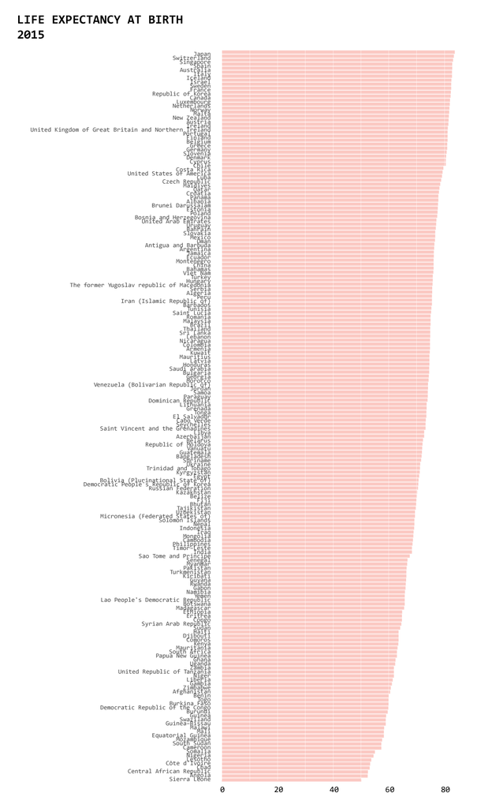

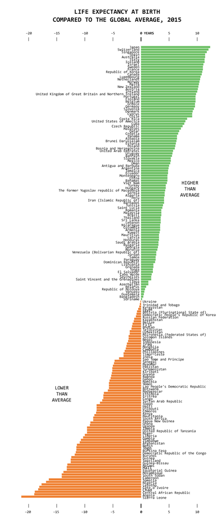

The worst two data representations are:

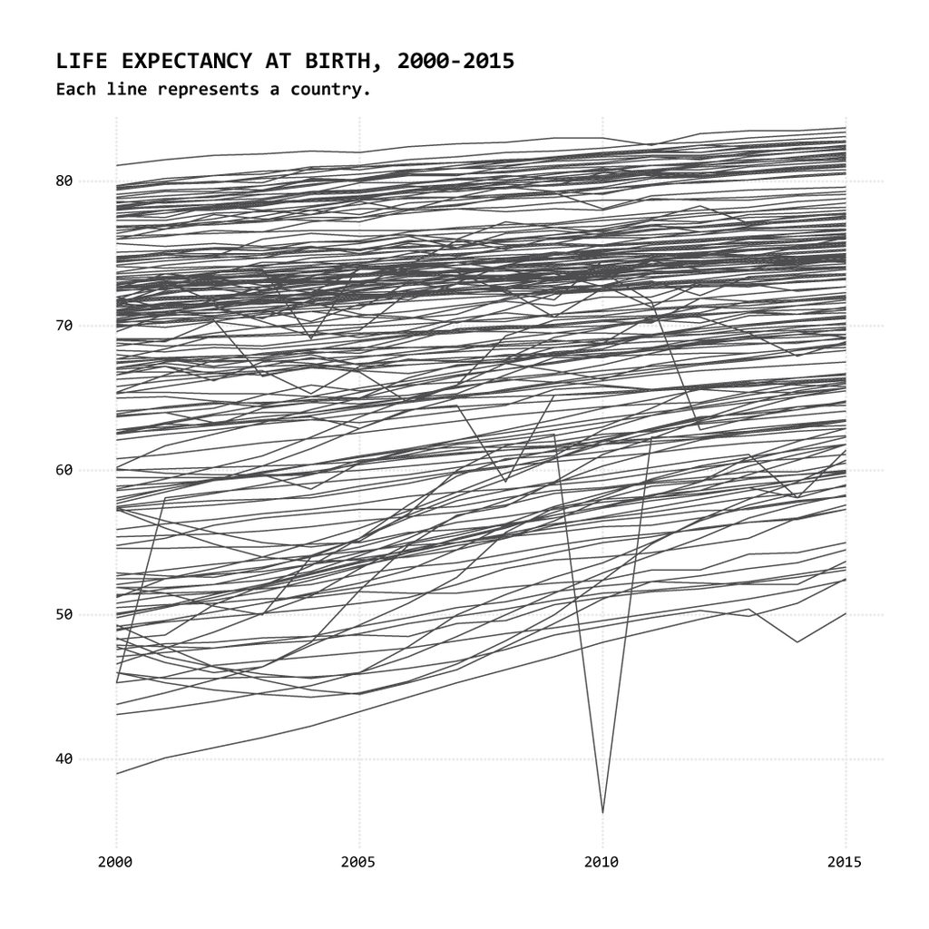

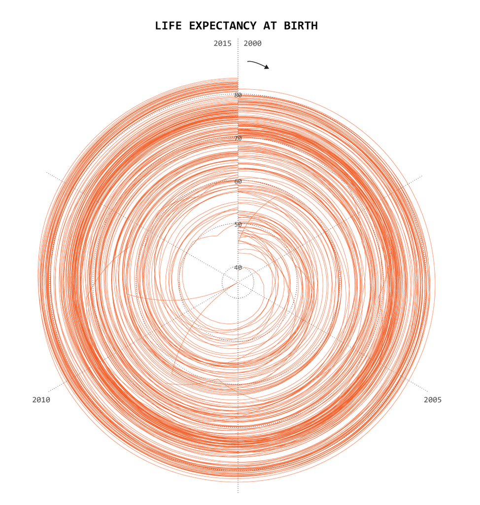

Here the main information (life expectancy in different countries) is not clearly represented and the labeling is not clear. Moreover, due to the overlapping lines it is impossible to compare and understand the life expectancy. Clearly, this method of representing data compared to the bar graphs used before is not appropriate.

## *Exercise 5*

We will need to repeat some probability theory. Read the first chapter on Probability theory from MathWiki web-site: http://mathwiki.cs.ut.ee/start. We recommend that you solve all the given exercises for training purposes. Play with the simulation of a dice. Explain how the increase of rolling times changes the probability distribution of the dice.

**Solution:**

Rolling a fair dice results in 6 elementary events, which have equal probability $\frac{1}{6}$.  
Obviously the minimum number of rolls of a fair dice to see all sides is $6$. The expected time required to roll every number is $14.7$ and the probability for this is $0.015$. So we expect to roll a dice about $15$ times on average before we observe all sides at least once. Using a table we can represent the elementary events with probabilities. This is called a probability distribution of an experiment/process (in our case probability distribution of the dice roll). The idea is that, each time you perform the experiment, you obtain a sample of the random variable. Since the variable is random, you expect to get different values as you obtain multiple samples. Using a large enough sample implies that even if a certain number has an increased probability, in a long run the other underrepresented numbers will appear enough times for the probability of every number to converge to $\frac{1}{6}$ as the sample size increases.

Solve the following tasks from Math wiki, describe it in detail (not just an answer) and make sure you can explain them for the audience:

A company makes computer discs. It tested a random sample of discs from a large batch and found that the probability of any disc being defective is $0.025$. Bob buys two discs. Calculate the probability that

1. both discs are defective;
2. that only one disc is defective.
3. The company found $4$ defective discs in the sample they tested. How many discs were likely tested?

**Solution:**

1. The probability that none of the discs works equals the probability that both discs fail. This is given by:

$$P(both fail)=P(F)P(F)=0.025*0.025=0.000625$$
b. If only one disc works then you could select the two discs in the following orders: $(FW)$ or $(WF)$. Hence:

$$P(W)=1-0.025=0.975$$
$$P(one fail)=P(W)P(F)+P(F)P(W)=0.04875$$
c. The number of the sample is $160$ disks. There are two approaches to solve this problem. First we can create a simple ration which will give us the number of nondefective disks.

$$\frac{4}{x}= \frac{0.025}{0.975}$$

$$x=156$$
If we add the 4 defective disks we get $160$.

Also we can use the formula of the classical probability which will give us the same result.

$$0.025=\frac{4}{x}$$

Also this type of problem is easily solvable using the binomial distribution.